# R Basics

Rüçhan Ekren

Jean Monlong

Margot Zahm

# Why R?

## Why R?

**Simple**

- Interpretative language (no compilation needed)
- No manual memory management
- Vectorized

**Free**

- Widely used, vast community of R users
- Good life expectancy

## Why R?

**Flexible**

- Open-source: anyone can see/create/modify
- Multiplatform: Windows, Mac, Unix… It works everywhere

**Trendy**

- More and more packages
- More and more popular among data scientists and (now) biologists

## Lots of bioinfo packages

[figure not shown]

## Workshop Setup

- Open

[figure not shown]

## Workshop Setup

- Open

[figure not shown]

[figure not shown]

## Workshop Setup

Open a new R script file (File > New File > R Script)

[figure not shown]

## Workshop Setup

**Console**

- Where R is running
- You can write and run the commands directly here
- Your command executes when you press Enter

## Workshop Setup

**Console**

**Script**

- A text file with commands. *Extension .R*
- To keep a trace of your analysis
- Highly recommended
- Run commands from a script to the console with Run button

## Workshop Setup

**Console**

**Script**

**Tracking panel**

- List all **variables** you generated
- An **history** of the commands you ran

## Workshop Setup

**Console**

**Script**

**Tracking panel**

**Multipurpose panel**

Check **files** in your computer, see **plots**, manage **packages**, read **help** section of a function.

## Workshop Setup

**Console**

**Script**

**Tracking panel**

**Multipurpose panel**

**Caution**

Write everything you do in scripts to avoid loosing your work.

## When you get an error

1. Read the command, look for typos
2. Read the error message
3. 1. and 2. again
4. Raise your hand, someone will assist you

**Tip**

Solving errors is an important skill to learn.

# Objects

## Objects - Overview

**Unit type**

- **numeric** e.g. numbers
- **logical Binary** two possible values
- **character** e.g. words between `"`
- **comment**: line starting by **#**

```r
# This is a comment line
# I can write everythin I want
```

**Tip**

Comment your script to help you remember what you have done.

## Objects - Overview

**Complex type**

- **vector**: Ordered collection of elements of the same type
- **list**: Flexible container, mixed type possible. Recursive

## Objects - Overview

**Complex type**

- **matrix**: Table of elements of the same type
- **data.frame**: Table of mixed type elements

**Note**

These are the basic complex types. It exists a lot of different complex objects which mix all these basic objects.

## Objects - Naming conventions

- Use letters, numbers, dot or underline characters
- Start with letter (or the dot not followed by a number)
- Some names are forbidden (eg. `if`, `else`, `TRUE`, `FALSE`)
- Correct: `valid.name`, `valid_name`, `valid2name3`
- Incorrect: `valid name`, `valid-name`, `1valid2name3`

**Tip**

Avoid random names such as `var1`, `var2`. Use significant names: `gene_list`, `nb_elements`

## Objects - Arithmetic operators

You can use operators on objects to modify them. Depending on the object format, operators have different behaviors and some are forbidden.

- addition: `+`
- subtraction: `-`
- multiplication: `*`
- division: `/`
- exponent: `^` or `**`
- integer division: `%/%`
- modulo: `%%`

## Objects - Arithmetic operators

**Exercise**

1. Create a numeric object
2. Multiply it by 6
3. Add 21
4. Divide it by 3
5. Subtract 1
6. Halve it
7. Subtract its original value

## Objects - Function

- A function is a tool to create or modify an object
- Format: `function_name(object, parameter1 = ..., parameter2 = ...)`
- Read the help manual to know more about a function (`help`, `?` or `F1`)

## Objects - Function

- A function is a tool to create or modify an object
- Format: `function_name(object, parameter1 = ..., parameter2 = ...)`
- Read the help manual to know more about a function (`help`, `?` or `F1`)

**Note**

Some functions are in the default installation of R. Other functions come from packages. You can also create your own functions.

# Vectors

## Vectors Creation

- `c()` Concatenate function is the most common way to create vectors
- `1:10` Easy way to create a vector with numbers from 1 to 10

## Vectors Creation

- `c()` Concatenate function is the most common way to create vectors
- `1:10` Easy way to create a vector with numbers from 1 to 10

**Extra ways to create vectors**

- `seq()` Create a sequence of numbers
- `rep()` Repeat elements several times
- `runif()` Simulate random numbers from Uniform distribution. Same for `rnorm()`, `rpois()`…

## Exercise - Create some vectors

**Instructions**

- Create a `vector` with 7 *numeric* values
- Create a `vector` with 7 *character* values

## Vectors Exploration

Using index/position between []

## Vectors Characterics

- `length()` Number of elements in the vector
- `names()` Get or set the names of the vector’s value. No value by default.

## Vectors Manipulation

- `sort()` Sort a vector
- `sample()` Shuffle a vector
- `rev()` Reverse a vector

**Extra**

- `log/log2/log10` Logarithm functions
- `sqrt` Square-root function

## Vectors Summary

- `head()/tail()` Print the first/last values
- `summary()` Summary statistics
- `min()/max()/mean()/median()/var()` Minimum, maximum, average, median, variance
- `sum` Sum of the vector’s values

## Vectors - Arithmetic operators

- Simple arithmetic operations over all the values of the vector
- Or values by values when using vectors of same length
- Arithmetic operations: +, -, *, /
- Other exist but let’s forget about them for now

## Exercise

**Instructions**

1. Create a vector with 100 random numeric values (hint: `runif` or `rnorm`)
2. Subtract the average of those values
3. Divide by the standard deviation
4. Multiply all the values by 10
5. Add 100 to all the values
6. Compute summary statistics (minimum/maximum, median, mean)
7. Compute the standard deviation of the new values

# Matrix

## Matrix - Creation

`matrix()`: Creates a matrix from a vector

`rbind()/cbind()`: Binds multiple vectors of a same length to create a matrix

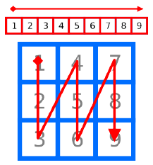

## Matrix - Manipulation

`mat[i,j]`: To select element at row *i* and column *j*. *i* and *j* can be vectors to select multiple elements.

## Matrix - Manipulation

`mat[i,j]`: To select element at row *i* and column *j*. *i* and *j* can be vectors to select multiple elements.

`t()`: To transpose the matrix

`rbind()/cbind()`: To concatenate matrix vertically or horizontally

## Exercise

**Instructions**

1. Create a matrix with 10 rows and 4 column with numbers from 1 to 40
2. Change the element in row 6, column 2 into value 42
3. Fill the 3rd row with ones
4. Remove the last column

## Matrix - Manipulation

`dim()`: Returns the dimension of the matrix, e.g. number of rows and columns `rownames()/colnames()`: Get or set the names of the rows/columns

## Matrix - Operations

`length()`, `head()`, `tail()`

For numeric matrix: `min()`, `max()`, `sum()`, `mean()`, `summary()`…

Arithmetic operations: `+`, `-`, `*`, `/`

## Exercise

**Instructions**

1. Create a matrix with 100 rows and 4 column with random numbers
2. Name the columns
3. Add 2 to each element of the first column
4. Multiply all the elements of the second column by 4
5. Find which column has the largest mean value
6. Find which column has the largest value

## Matrix - `apply()` function

- Apply a function to each row (or column) of a matrix
- No manual iteration, the loop is implicit
- Second parameter: `1` means row and `2` means columns

## Exercise

**Instructions**

1. Create a matrix with 100 rows and 100 column with random numbers
2. Compute the median value of each column
3. What is the minimal median value? Maximal?

## Reminder of last session

**Objects**

- There are three basic types of objects: `numeric`, `character` and `boolean`
- Basic objects can be combined into more complex objects, such as `vector`s, `list`s, `matrice`s and `data.frame`s
- Objects need to be ‘stored’ in variables so they can be easily retrieved and modified
- Basic and complex numeric objects can handle arithmetic operations
- Functions can be applied to basic and/or complex objects depending on the type of data they are designed to process

## Reminder of last session

**Vectors**

- A `vector` is a sequence of elements that are all of the same type
- There are multiple ways to create it
- `[]` are used to manipulate elements of a vector
- Numeric vectors support arithmetic operations
- Elements in a vector can be named
- Various functions can be used with vectors to modify or summarize them

## Reminder of last session

**Matrix**

- A `matrix` is a table containing elements of one data type
- `matrix()`: function to create a matrix
- `[i,j]`: used to manipulate and replace elements
- `rownames()`, `colnames()`: get/set the row or column names
- Numeric tables support arithmetic operations
- `apply()`: run a function on each row or column

# Data Frames

## Data frames - Creation

A data frame is like a matrix but it can be composed of different data types.

- `data.frame()` To create a data frame
- `as.data.frame()` To transform a matrix into a data frame

## Data frames - Manipulation

- `[]` or `$name` To select elements of a data.frame
- `t()` To transpose
- `head()/tail()` To show parts of a data frame

## Data frames - Summarize and concatenation

`dim()`: Returns the dimension of the data frame, e.g. number of rows and columns `rownames()/colnames()`: Get or set the names of the rows/columns `rbind()/cbind()`: To concatenate data frame vertically or horizontally

## Exercise

**Instructions**

1. Create a data frame of 100 rows with a character column and two numeric columns
2. Display the first few rows of this data frame
3. Calculate the mean of the two numeric columns
4. Add a new column containing boolean values

## Data frames - Calculation

You can use arithmetic operations (`+-*/`) only on numeric columns. Functions like `apply()` can be used as with a matrix.

## Exercise

**Instructions**

1. Create a data frame with 2000 random gene names, and 3 columns with random numerics between 0 and 1
2. Multiply numeric column 1 by 100, numeric column 1 by 200 and numeric column 3 by 300
3. Find the column with the highest average expression
4. Find the gene with the lowest median expression

# Import/Export data

## Import/Export data - Where is my data ?

**File path**

To tell R where to find your data, you need to specify the path to the file. There are two types of paths for the same file:

- **Absolute Path**: This is the full path to the file, which you can see in the address bar when you are in a folder.
- **Relative Path**: This describes how to navigate from one folder to another to reach the file.

Paths are always enclosed in double quotes (`"`).

## Import/Export data - Where is my data ?

**Working directory**

Change the directory where R is working

[figure not shown]

## Import/Export data - Read a text file

**Easy but important**

- What data structure is more appropriate? vector, matrix?
- Does R read/write the file the way you want?
- The extra parameters of the functions are your allies

## Import/Export data - Read a text file

**read.table()**

To read a data.frame from a multi-column file

- `file=`the path to the file
- `header=` Set to TRUE if the 1st line correspond to column names
- `as.is=` Set to TRUE to read the values as simple type, **recommended**
- `sep=` The character that separate the columns, e.g. `,` or `\t` (tabs)
- `row.names=` The column number to use as row names ``

```r
input.data = read.table("path/to/my/file.txt", as.is = TRUE,
                        header = TRUE, sep = "\t", row.names = 1)
```

## Exercise

**Instructions**

Import dataForBasicPlots.tsv into an object called mat.ge

1. How many genes are there?
2. How many samples are there?
3. Print the first 5 rows and columns

## Import/Export data - Write a text file

**write.table()**

To write a data.frame in a multi-column file

- `df` the data.frame to write
- `file=` the file name
- `col.names=` TRUE print the column names in the first line
- `row.names=` TRUE print the row names in the first columns
- `quote=` TRUE surround character by double quotes
- `sep=` the character that separates each column. ’ ’ by default.

```r
write.table(resToWrite, file = "path/to/file.txt", col.names = TRUE,
            row.names = FALSE, quote = FALSE, sep = "\t")
```

## Import/Export data - R objects

- `saveRDS()` Save one R object into a file. Use *.rds* extension
- `save()` Save multiple R objects into a file. Use *.RData* as extension
- `save.image()` Save the entire R environment
- `readRDS()` Read a R object from a *.rds* file
- `load()` Load R objects from a *.RData* file

```r
saveRDS(luckyNumbers, file = "my_vector.rds")
new_luckyNumber = readRDS("my_vector.rds")

save(luckyNumbers, tenOnes, mat, file = "uselessData.RData")
load("uselessData.RData")
```

## Import/Export data - Save plots

**Easy way**

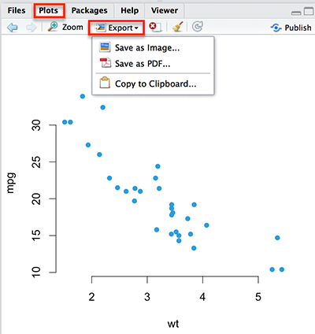

## Import/Export data - Save plots

**Automatic way**

1. Open the connection to an output file (`pdf()`, `png()`, `jpeg()`…)
2. Plot as usual
3. close the connection with `dev.off()`

```r
pdf("/path/to/myNicePlot.pdf")
plot(...)
dev.off()
```

# Basic plotting

## Basic plotting - Functions

**`hist(x)`**

Plot a histogram, eg. the value distribution of a vector.

`x` The vector with the values to plot

## Basic plotting - Functions

**`barplot(x)`**

Plot a barplot, eg. one bar for each value of a vector.

`x` The vector with the values to plot

## Basic plotting - Functions

**`plot(x, y)`**

Plot one vector against the other using points for each element.

`x` The first vector to plot (*x-axis*)

`y` The second vector to plot (*y-axis*)

`type` How the points are plotted. “p” for points, “l” for points joined by lines

## Basic plotting - Functions

**`boxplot(x)`**

Plot the distribution of variables.

`x` The matrix of distributions

## Basic plotting - Common parameters

`main=` A title for te plot

`xlab=/ylab=` A title for the x/y axis

`xlim=/ylim=` A vector of size two defining the desired limits on the x/y axis

## Basic plotting - Extra

**Extra parameters**

`col=` The colour of the points/lines

`pch=` The shape of the points

`lty=` The shape of the lines

**Extra functions**

`lines()` Same as plot but super-imposed to the existent one `abline()` Draw a vertical/horizontal line

## Exercise

**Instructions**

Generate plots using the dataForBasicPlots.tsv file and save them:

1. a boxplot of columns 1 to 10.
2. the distribution of the median gene expression. Add a vertical dotted line to mark the average of the median gene expression.
3. the expression of gene 333 against gene 666. Surimpose in red triangles the expression of gene 333 against gene 667.

## Reminder of last session

**“Table” objects**

- A `matrix` is a table containing elements of one data type
- A `data.frame` is a table with columns of different data types
- `matrix()`, `data.frame()`: functions to create a matrix or a data frame
- `[i,j]`: used to manipulate and replace elements
- `rownames()`, `colnames()`: get/set the row or column names
- Numeric columns support arithmetic operations
- `apply()`: run a function on each row or column

## Reminder of last session

**Read and write files in R**

- Set your working directory, eg. the folder where you are working (Session > Set Working Directory)
- You can get the path of your file if you copy/paste it on R
- `read.table()`: Basic function to read a table
- `write.table()`: Basic function to write a table
- `pdf()/png()/jpeg() ... dev.off()`: Save a plot in PDF/PNG/JPEG format automatically
- You can save R objects/environments (`saveRDS()`, `save()`, `save.image()`)
- You can load R objects/environments (`readRDS()`, `load()`)

## Reminder of last session

**Plot**

- There are different functions to plot data
- `barplot()`
- `hist()`
- `boxplot()`
- `plot()` : Scatter plot with points and/or lines
- Some parameters can be used to custom your plot : `main=`, `xlab=`, `xlim=` …